# Tarea 7

Victor Quintero Marmol Gonzalez 175897

April 27, 2018

Se crea cluster

[figure not shown]

Se muestra diagrama de elementos del código, donde se representa con verde DataFrames, con azul transformers, gris estimadores y blanco diccionarios para el grid search:

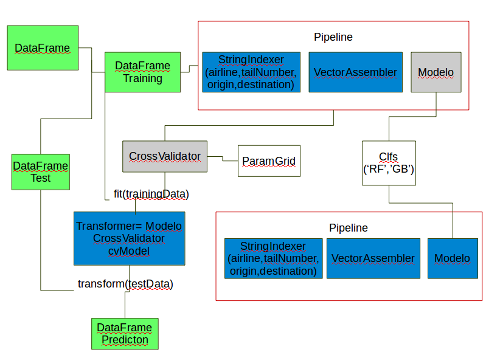

El script a correr se puede ver en el archivo *script.py*. Además se agrega el archivo *Tarea_7.json* que es el zeppelin que se ocupó.

Se pone evidencia de que el script se ejecutó correctamente:

[figure not shown]

Los algoritmos que se ocuparon fueron Random Forest y Gradient Boosting.

## Preguntas:

### ¿Qué parámetros resultaron mejor por algoritmo?

Los mejores parámetros para Gradient Boosting fueron:

{ GBTRegressor_44f5a2b1652e23f52302-cacheNodeIds: false, GBTRegressor_44f5a2b1652e23f52302-checkpointInterval: 10, GBTRegressor_44f5a2b1652e23f52302-featuresCol: features, GBTRegressor_44f5a2b1652e23f52302-impurity: variance, GBTRegressor_44f5a2b1652e23f52302-labelCol: DEPARTURE_DELAY, GBTRegressor_44f5a2b1652e23f52302-lossType: squared, GBTRegressor_44f5a2b1652e23f52302-maxBins: 800, GBTRegressor_44f5a2b1652e23f52302-maxDepth: 5, GBTRegressor_44f5a2b1652e23f52302-maxIter: 5, GBTRegressor_44f5a2b1652e23f52302-maxMemoryInMB: 256, GBTRegressor_44f5a2b1652e23f52302-minInfoGain: 0.0, GBTRegressor_44f5a2b1652e23f52302-minInstancesPerNode: 1, GBTRegressor_44f5a2b1652e23f52302-predictionCol: prediction, GBTRegressor_44f5a2b1652e23f52302-seed: -6363326153609583521, GBTRegressor_44f5a2b1652e23f52302-stepSize: 0.1, GBTRegressor_44f5a2b1652e23f52302-subsamplingRate: 1.0 }

Evidencia en cluster:

[figure not shown]

Los mejores parámetros para Random Forest fueron:

{ RandomForestRegressor_4d8f98d1f9210b258efd-cacheNodeIds: false, RandomForestRegressor_4d8f98d1f9210b258efd-checkpointInterval: 10, RandomForestRegressor_4d8f98d1f9210b258efd-featureSubsetStrategy: auto, RandomForestRegressor_4d8f98d1f9210b258efd-featuresCol: features, RandomForestRegressor_4d8f98d1f9210b258efd-impurity: variance, RandomForestRegressor_4d8f98d1f9210b258efd-labelCol: DEPARTURE_DELAY, RandomForestRegressor_4d8f98d1f9210b258efd-maxBins: 900, RandomForestRegressor_4d8f98d1f9210b258efd-maxDepth: 5, RandomForestRegressor_4d8f98d1f9210b258efd-maxMemoryInMB: 256, RandomForestRegressor_4d8f98d1f9210b258efd-minInfoGain: 0.0, RandomForestRegressor_4d8f98d1f9210b258efd-minInstancesPerNode: 1, RandomForestRegressor_4d8f98d1f9210b258efd-numTrees: 5, RandomForestRegressor_4d8f98d1f9210b258efd-predictionCol: prediction, RandomForestRegressor_4d8f98d1f9210b258efd-seed: -5851613654371098793, RandomForestRegressor_4d8f98d1f9210b258efd-subsamplingRate: 1.0 }

[figure not shown]

### ¿Qué algoritmo resultó el mejor, con qué parámetros?

Para elegir el mejor modelo se usó la metrica de error cuadrático medio (RMSE), dando los siguientes resultados

| Modelo | RMSE |
| --- | --- |
| GB | 8.431378154849645 |
| RF | 14.662438802560672 |

Evidencia en cluster:

[figure not shown]

Por lo que el mejor modelo fue Gradient Boosting con los parámetros descritos anteriormente:

maxBins: 800 maxDepth: 5 maxIter: 5

{ GBTRegressor_44f5a2b1652e23f52302-cacheNodeIds: false, GBTRegressor_44f5a2b1652e23f52302-checkpointInterval: 10, GBTRegressor_44f5a2b1652e23f52302-featuresCol: features, GBTRegressor_44f5a2b1652e23f52302-impurity: variance, GBTRegressor_44f5a2b1652e23f52302-labelCol: DEPARTURE_DELAY, GBTRegressor_44f5a2b1652e23f52302-lossType: squared, GBTRegressor_44f5a2b1652e23f52302-maxBins: 800, GBTRegressor_44f5a2b1652e23f52302-maxDepth: 5, GBTRegressor_44f5a2b1652e23f52302-maxIter: 5, GBTRegressor_44f5a2b1652e23f52302-maxMemoryInMB: 256, GBTRegressor_44f5a2b1652e23f52302-minInfoGain: 0.0, GBTRegressor_44f5a2b1652e23f52302-minInstancesPerNode: 1, GBTRegressor_44f5a2b1652e23f52302-predictionCol: prediction, GBTRegressor_44f5a2b1652e23f52302-seed: -6363326153609583521, GBTRegressor_44f5a2b1652e23f52302-stepSize: 0.1, GBTRegressor_44f5a2b1652e23f52302-subsamplingRate: 1.0 }

El tiempo de ejecución del magic_loop fue de 2 hrs 20 min 27 sec de acuerdo a zeppelin, no se uso la función timeit por problemas de java en el cluster.